# FORD_GoBike Data Exploration

-Introduction

-Gathering Data

-Assessing Data

-Cleaning Data

-Univariate Exploration

-Bivariate Exploration

-Multivariate Exploration

### Introduction

Ford GoBike is a regional public bicycle sharing system in the San Francisco Bay Area, California. Beginning operation in August 2013 as Bay Area Bike Share, the Ford GoBike system currently has over 2,600 bicycles in 262 stations across San Francisco, East Bay and San Jose. On June 28, 2017, the system officially launched as Ford GoBike in a partnership with Ford Motor Company.

Ford GoBike, like other bike share systems, consists of a fleet of specially designed, sturdy and durable bikes that are locked into a network of docking stations throughout the city. The bikes can be unlocked from one station and returned to any other station in the system, making them ideal for one-way trips. The bikes are available for use 24 hours/day, 7 days/week, 365 days/year and riders have access to all bikes in the network when they become a member or purchase a pass.

### Data Gathering

```python
# import all packages and set plots to be embedded inline
import numpy as np
import pandas as pd
import matplotlib.pyplot as plt
import seaborn as sb
import datetime

import glob
import os

%matplotlib inline
```

###### Gathering involves following steps:

```python
#1.Downloading tripdataset.csv files from "https://www.lyft.com/bikes/bay-wheels/system-data" and saving them in the path specified below.

path=r'C:\Users\deeps\Documents\UDACITY\FORDGOBIKE_Dataset'

files=glob.glob(os.path.join(path,"*.csv"))
```

```python
#2.concatenate all the data from the downloaded files into a single dataframe
df = pd.concat((pd.read_csv(f) for f in files), ignore_index = True)
```

```python
#3.store dataframe into a csv file
df.to_csv(r'C:\Users\deeps\Documents\UDACITY\Data_visu\fordgo.csv', index = False)
```

```python
df
```

|  | duration_sec | start_time | end_time | start_station_id | start_station_name | start_station_latitude | start_station_longitude | end_station_id | end_station_name | end_station_latitude | end_station_longitude | bike_id | user_type | member_birth_year | member_gender | bike_share_for_all_trip |
| --- | --- | --- | --- | --- | --- | --- | --- | --- | --- | --- | --- | --- | --- | --- | --- | --- |
| 0 | 75284 | 2018-01-31 22:52:35.2390 | 2018-02-01 19:47:19.8240 | 120.0 | Mission Dolores Park | 37.761420 | -122.426435 | 285.0 | Webster St at O'Farrell St | 37.783521 | -122.431158 | 2765 | Subscriber | 1986.0 | Male | No |
| 1 | 85422 | 2018-01-31 16:13:34.3510 | 2018-02-01 15:57:17.3100 | 15.0 | San Francisco Ferry Building (Harry Bridges Pl... | 37.795392 | -122.394203 | 15.0 | San Francisco Ferry Building (Harry Bridges Pl... | 37.795392 | -122.394203 | 2815 | Customer | NaN | NaN | No |
| 2 | 71576 | 2018-01-31 14:23:55.8890 | 2018-02-01 10:16:52.1160 | 304.0 | Jackson St at 5th St | 37.348759 | -121.894798 | 296.0 | 5th St at Virginia St | 37.325998 | -121.877120 | 3039 | Customer | 1996.0 | Male | No |
| 3 | 61076 | 2018-01-31 14:53:23.5620 | 2018-02-01 07:51:20.5000 | 75.0 | Market St at Franklin St | 37.773793 | -122.421239 | 47.0 | 4th St at Harrison St | 37.780955 | -122.399749 | 321 | Customer | NaN | NaN | No |
| 4 | 39966 | 2018-01-31 19:52:24.6670 | 2018-02-01 06:58:31.0530 | 74.0 | Laguna St at Hayes St | 37.776435 | -122.426244 | 19.0 | Post St at Kearny St | 37.788975 | -122.403452 | 617 | Subscriber | 1991.0 | Male | No |
| 5 | 6477 | 2018-01-31 22:58:44.8670 | 2018-02-01 00:46:41.9080 | 236.0 | Market St at 8th St | 37.803686 | -122.282497 | 160.0 | West Oakland BART Station | 37.805318 | -122.294837 | 1306 | Customer | NaN | NaN | No |
| 6 | 453 | 2018-01-31 23:53:53.6320 | 2018-02-01 00:01:26.8050 | 110.0 | 17th & Folsom Street Park (17th St at Folsom St) | 37.763708 | -122.415204 | 134.0 | Valencia St at 24th St | 37.752428 | -122.420628 | 3571 | Subscriber | 1988.0 | Male | No |
| 7 | 180 | 2018-01-31 23:52:09.9030 | 2018-01-31 23:55:10.8070 | 81.0 | Berry St at 4th St | 37.775880 | -122.393170 | 93.0 | 4th St at Mission Bay Blvd S | 37.770407 | -122.391198 | 1403 | Subscriber | 1980.0 | Male | No |
| 8 | 996 | 2018-01-31 23:34:56.0040 | 2018-01-31 23:51:32.6740 | 134.0 | Valencia St at 24th St | 37.752428 | -122.420628 | 4.0 | Cyril Magnin St at Ellis St | 37.785881 | -122.408915 | 3675 | Subscriber | 1987.0 | Male | Yes |
| 9 | 825 | 2018-01-31 23:34:14.0270 | 2018-01-31 23:47:59.8090 | 305.0 | Ryland Park | 37.342725 | -121.895617 | 317.0 | San Salvador St at 9th St | 37.333955 | -121.877349 | 1453 | Subscriber | 1994.0 | Female | Yes |
| 10 | 1316 | 2018-01-31 23:24:00.4160 | 2018-01-31 23:45:56.8240 | 98.0 | Valencia St at 16th St | 37.765052 | -122.421866 | 4.0 | Cyril Magnin St at Ellis St | 37.785881 | -122.408915 | 1278 | Customer | NaN | NaN | No |
| 11 | 432 | 2018-01-31 23:34:26.4840 | 2018-01-31 23:41:39.2970 | 89.0 | Division St at Potrero Ave | 37.769218 | -122.407646 | 43.0 | San Francisco Public Library (Grove St at Hyde... | 37.778768 | -122.415929 | 2928 | Subscriber | 1993.0 | Male | No |
| 12 | 601 | 2018-01-31 23:29:46.8320 | 2018-01-31 23:39:48.0000 | 223.0 | 16th St Mission BART Station 2 | 37.764765 | -122.420091 | 86.0 | Market St at Dolores St | 37.769305 | -122.426826 | 3016 | Subscriber | 1957.0 | Male | No |
| 13 | 887 | 2018-01-31 23:24:16.3570 | 2018-01-31 23:39:04.1230 | 308.0 | San Pedro Square | 37.336802 | -121.894090 | 297.0 | Locust St at Grant St | 37.322980 | -121.887931 | 55 | Subscriber | 1976.0 | Female | Yes |
| 14 | 210 | 2018-01-31 23:33:03.0460 | 2018-01-31 23:36:33.7040 | 7.0 | Frank H Ogawa Plaza | 37.804562 | -122.271738 | 186.0 | Lakeside Dr at 14th St | 37.801319 | -122.262642 | 2602 | Subscriber | 1976.0 | Male | No |
| 15 | 188 | 2018-01-31 23:30:58.1360 | 2018-01-31 23:34:06.3910 | 98.0 | Valencia St at 16th St | 37.765052 | -122.421866 | 76.0 | McCoppin St at Valencia St | 37.771662 | -122.422423 | 2556 | Subscriber | 1964.0 | Female | No |
| 16 | 808 | 2018-01-31 23:19:58.6030 | 2018-01-31 23:33:27.5310 | 67.0 | San Francisco Caltrain Station 2 (Townsend St... | 37.776639 | -122.395526 | 98.0 | Valencia St at 16th St | 37.765052 | -122.421866 | 3041 | Subscriber | 1976.0 | Male | Yes |
| 17 | 378 | 2018-01-31 23:23:23.0680 | 2018-01-31 23:29:42.0440 | 80.0 | Townsend St at 5th St | 37.775306 | -122.397380 | 78.0 | Folsom St at 9th St | 37.773717 | -122.411647 | 546 | Subscriber | 1995.0 | Female | No |
| 18 | 350 | 2018-01-31 23:13:45.5290 | 2018-01-31 23:19:36.2650 | 247.0 | Fulton St at Bancroft Way | 37.867789 | -122.265896 | 274.0 | Oregon St at Adeline St | 37.857567 | -122.267558 | 431 | Subscriber | NaN | NaN | No |
| 19 | 686 | 2018-01-31 23:07:15.3130 | 2018-01-31 23:18:41.5580 | 312.0 | San Jose Diridon Station | 37.329732 | -121.901782 | 317.0 | San Salvador St at 9th St | 37.333955 | -121.877349 | 1886 | Subscriber | 1997.0 | Female | No |
| 20 | 450 | 2018-01-31 23:07:13.0630 | 2018-01-31 23:14:43.8140 | 241.0 | Ashby BART Station | 37.852477 | -122.270213 | 157.0 | 65th St at Hollis St | 37.846784 | -122.291376 | 3583 | Subscriber | 1994.0 | Male | No |
| 21 | 294 | 2018-01-31 23:08:12.0000 | 2018-01-31 23:13:06.6360 | 239.0 | Bancroft Way at Telegraph Ave | 37.868813 | -122.258764 | 244.0 | Shattuck Ave at Hearst Ave | 37.873792 | -122.268618 | 2144 | Subscriber | 1983.0 | Male | No |
| 22 | 150 | 2018-01-31 23:10:09.5860 | 2018-01-31 23:12:40.3330 | 182.0 | 19th Street BART Station | 37.809013 | -122.268247 | 183.0 | Telegraph Ave at 19th St | 37.808702 | -122.269927 | 3468 | Subscriber | 1945.0 | Male | Yes |
| 23 | 462 | 2018-01-31 23:03:48.9400 | 2018-01-31 23:11:31.0290 | 119.0 | 18th St at Noe St | 37.761047 | -122.432642 | 134.0 | Valencia St at 24th St | 37.752428 | -122.420628 | 1432 | Subscriber | 1971.0 | Male | Yes |
| 24 | 379 | 2018-01-31 23:04:27.7010 | 2018-01-31 23:10:46.9760 | 176.0 | MacArthur BART Station | 37.828410 | -122.266315 | 189.0 | Genoa St at 55th St | 37.839649 | -122.271756 | 997 | Subscriber | 1975.0 | Male | No |
| 25 | 880 | 2018-01-31 22:53:41.3020 | 2018-01-31 23:08:21.4430 | 123.0 | Folsom St at 19th St | 37.760594 | -122.414817 | 145.0 | 29th St at Church St | 37.743684 | -122.426806 | 3725 | Subscriber | 1986.0 | Male | No |
| 26 | 1210 | 2018-01-31 22:45:37.1250 | 2018-01-31 23:05:47.5760 | 285.0 | Webster St at O'Farrell St | 37.783521 | -122.431158 | 133.0 | Valencia St at 22nd St | 37.755213 | -122.420975 | 1059 | Subscriber | 1991.0 | Male | No |
| 27 | 259 | 2018-01-31 23:01:12.7920 | 2018-01-31 23:05:32.1570 | 239.0 | Bancroft Way at Telegraph Ave | 37.868813 | -122.258764 | 266.0 | Parker St at Fulton St | 37.862464 | -122.264791 | 1208 | Subscriber | 1994.0 | Male | No |
| 28 | 592 | 2018-01-31 22:53:27.7790 | 2018-01-31 23:03:20.2900 | 202.0 | Washington St at 8th St | 37.800754 | -122.274894 | 195.0 | Bay Pl at Vernon St | 37.812314 | -122.260779 | 1834 | Customer | 1978.0 | Male | No |
| 29 | 1059 | 2018-01-31 22:45:16.5700 | 2018-01-31 23:02:56.2850 | 141.0 | Valencia St at Cesar Chavez St | 37.747998 | -122.420219 | 79.0 | 7th St at Brannan St | 37.773492 | -122.403673 | 1248 | Subscriber | 1988.0 | Male | No |
| ... | ... | ... | ... | ... | ... | ... | ... | ... | ... | ... | ... | ... | ... | ... | ... | ... |
| 1949055 | 135 | 2019-01-01 00:37:22.9770 | 2019-01-01 00:39:38.3130 | 138.0 | Jersey St at Church St | 37.750900 | -122.427411 | 145.0 | 29th St at Church St | 37.743684 | -122.426806 | 4940 | Subscriber | 1985.0 | Male | No |
| 1949056 | 1767 | 2019-01-01 00:08:39.6590 | 2019-01-01 00:38:06.8480 | 16.0 | Steuart St at Market St | 37.794130 | -122.394430 | 115.0 | Jackson Playground | 37.765026 | -122.398773 | 1705 | Customer | 1990.0 | Male | No |
| 1949057 | 552 | 2019-01-01 00:28:45.4970 | 2019-01-01 00:37:58.1320 | 23.0 | The Embarcadero at Steuart St | 37.791464 | -122.391034 | 24.0 | Spear St at Folsom St | 37.789677 | -122.390428 | 3346 | Customer | NaN | NaN | No |
| 1949058 | 529 | 2019-01-01 00:28:43.4240 | 2019-01-01 00:37:33.1830 | 23.0 | The Embarcadero at Steuart St | 37.791464 | -122.391034 | 24.0 | Spear St at Folsom St | 37.789677 | -122.390428 | 3062 | Customer | NaN | NaN | No |
| 1949059 | 780 | 2019-01-01 00:24:27.0200 | 2019-01-01 00:37:27.4390 | 109.0 | 17th St at Valencia St | 37.763316 | -122.421904 | 91.0 | Berry St at King St | 37.771762 | -122.398438 | 4982 | Subscriber | 1984.0 | Female | No |
| 1949060 | 620 | 2019-01-01 00:26:04.6330 | 2019-01-01 00:36:25.4090 | 27.0 | Beale St at Harrison St | 37.788059 | -122.391865 | 90.0 | Townsend St at 7th St | 37.771058 | -122.402717 | 5373 | Customer | 1991.0 | Male | No |
| 1949061 | 419 | 2019-01-01 00:29:17.5270 | 2019-01-01 00:36:17.2970 | 44.0 | Civic Center/UN Plaza BART Station (Market St ... | 37.781074 | -122.411738 | 26.0 | 1st St at Folsom St | 37.787290 | -122.394380 | 4654 | Subscriber | 1993.0 | Male | No |
| 1949062 | 325 | 2019-01-01 00:30:21.9750 | 2019-01-01 00:35:47.0920 | 95.0 | Sanchez St at 15th St | 37.766219 | -122.431060 | 73.0 | Pierce St at Haight St | 37.771793 | -122.433708 | 3034 | Subscriber | 1993.0 | Male | No |
| 1949063 | 922 | 2019-01-01 00:19:42.4100 | 2019-01-01 00:35:05.2420 | 62.0 | Victoria Manalo Draves Park | 37.777791 | -122.406432 | 336.0 | Potrero Ave and Mariposa St | 37.763281 | -122.407377 | 4772 | Subscriber | 1971.0 | Female | No |
| 1949064 | 883 | 2019-01-01 00:20:12.6990 | 2019-01-01 00:34:56.0160 | 71.0 | Broderick St at Oak St | 37.773063 | -122.439078 | 49.0 | S Park St at 3rd St | 37.780760 | -122.394989 | 5182 | Subscriber | 1975.0 | Male | No |
| 1949065 | 408 | 2019-01-01 00:28:01.5630 | 2019-01-01 00:34:50.2370 | 7.0 | Frank H Ogawa Plaza | 37.804562 | -122.271738 | 179.0 | Telegraph Ave at 27th St | 37.816073 | -122.267886 | 2705 | Subscriber | 1983.0 | Male | No |
| 1949066 | 432 | 2019-01-01 00:26:44.3930 | 2019-01-01 00:33:56.6210 | 23.0 | The Embarcadero at Steuart St | 37.791464 | -122.391034 | 28.0 | The Embarcadero at Bryant St | 37.787168 | -122.388098 | 2367 | Customer | 1987.0 | Male | No |
| 1949067 | 821 | 2019-01-01 00:18:51.3980 | 2019-01-01 00:32:33.1160 | 23.0 | The Embarcadero at Steuart St | 37.791464 | -122.391034 | 79.0 | 7th St at Brannan St | 37.773492 | -122.403673 | 4384 | Subscriber | 1993.0 | Male | No |
| 1949068 | 300 | 2019-01-01 00:27:04.3740 | 2019-01-01 00:32:04.5600 | 23.0 | The Embarcadero at Steuart St | 37.791464 | -122.391034 | 28.0 | The Embarcadero at Bryant St | 37.787168 | -122.388098 | 2899 | Customer | NaN | NaN | No |
| 1949069 | 422 | 2019-01-01 00:24:59.2450 | 2019-01-01 00:32:01.7100 | 119.0 | 18th St at Noe St | 37.761047 | -122.432642 | 98.0 | Valencia St at 16th St | 37.765052 | -122.421866 | 4745 | Subscriber | 1994.0 | Male | No |
| 1949070 | 830 | 2019-01-01 00:17:16.4960 | 2019-01-01 00:31:07.3800 | 23.0 | The Embarcadero at Steuart St | 37.791464 | -122.391034 | 90.0 | Townsend St at 7th St | 37.771058 | -122.402717 | 4983 | Subscriber | 1984.0 | Male | No |
| 1949071 | 842 | 2019-01-01 00:16:59.8030 | 2019-01-01 00:31:02.5000 | 23.0 | The Embarcadero at Steuart St | 37.791464 | -122.391034 | 90.0 | Townsend St at 7th St | 37.771058 | -122.402717 | 4811 | Subscriber | 1988.0 | Female | No |
| 1949072 | 499 | 2019-01-01 00:22:40.6170 | 2019-01-01 00:31:00.0290 | 24.0 | Spear St at Folsom St | 37.789677 | -122.390428 | 64.0 | 5th St at Brannan St | 37.776754 | -122.399018 | 4657 | Subscriber | 1986.0 | Male | Yes |
| 1949073 | 841 | 2019-01-01 00:16:58.8470 | 2019-01-01 00:30:59.9930 | 23.0 | The Embarcadero at Steuart St | 37.791464 | -122.391034 | 90.0 | Townsend St at 7th St | 37.771058 | -122.402717 | 5357 | Customer | 1982.0 | Male | No |
| 1949074 | 275 | 2019-01-01 00:23:40.7720 | 2019-01-01 00:28:16.6070 | 196.0 | Grand Ave at Perkins St | 37.808894 | -122.256460 | 200.0 | 2nd Ave at E 18th St | 37.800214 | -122.253810 | 4486 | Subscriber | 1990.0 | Male | No |
| 1949075 | 277 | 2019-01-01 00:23:34.4210 | 2019-01-01 00:28:11.9930 | 120.0 | Mission Dolores Park | 37.761420 | -122.426435 | 98.0 | Valencia St at 16th St | 37.765052 | -122.421866 | 5262 | Subscriber | 1993.0 | Male | No |
| 1949076 | 553 | 2019-01-01 00:18:03.1970 | 2019-01-01 00:27:16.3370 | 182.0 | 19th Street BART Station | 37.809013 | -122.268247 | 193.0 | Grand Ave at Santa Clara Ave | 37.812744 | -122.247215 | 510 | Subscriber | 1989.0 | Male | Yes |
| 1949077 | 112 | 2019-01-01 00:25:23.2890 | 2019-01-01 00:27:15.5510 | 308.0 | San Pedro Square | 37.336802 | -121.894090 | 308.0 | San Pedro Square | 37.336802 | -121.894090 | 4002 | Customer | 1992.0 | Male | No |
| 1949078 | 710 | 2019-01-01 00:14:48.3980 | 2019-01-01 00:26:38.4210 | 163.0 | Lake Merritt BART Station | 37.797320 | -122.265320 | 159.0 | 24th St at Market St | 37.816060 | -122.278244 | 4892 | Customer | 1999.0 | Female | No |
| 1949079 | 606 | 2019-01-01 00:14:55.9210 | 2019-01-01 00:25:02.2150 | 23.0 | The Embarcadero at Steuart St | 37.791464 | -122.391034 | 91.0 | Berry St at King St | 37.771762 | -122.398438 | 5112 | Subscriber | 1990.0 | Male | No |
| 1949080 | 390 | 2019-01-01 00:16:36.8450 | 2019-01-01 00:23:07.2530 | 109.0 | 17th St at Valencia St | 37.763316 | -122.421904 | 141.0 | Valencia St at Cesar Chavez St | 37.747998 | -122.420219 | 5059 | Subscriber | 1986.0 | Male | No |
| 1949081 | 227 | 2019-01-01 00:17:40.9750 | 2019-01-01 00:21:28.4180 | 73.0 | Pierce St at Haight St | 37.771793 | -122.433708 | 96.0 | Dolores St at 15th St | 37.766210 | -122.426614 | 4659 | Subscriber | 1987.0 | Male | No |
| 1949082 | 565 | 2019-01-01 00:11:03.4410 | 2019-01-01 00:20:29.2680 | 269.0 | Telegraph Ave at Carleton St | 37.862320 | -122.258801 | 243.0 | Bancroft Way at College Ave | 37.869360 | -122.254337 | 4783 | Subscriber | 1998.0 | Male | Yes |
| 1949083 | 182 | 2019-01-01 00:09:56.2110 | 2019-01-01 00:12:58.7480 | 269.0 | Telegraph Ave at Carleton St | 37.862320 | -122.258801 | 240.0 | Haste St at Telegraph Ave | 37.866043 | -122.258804 | 4621 | Subscriber | 1999.0 | Male | Yes |
| 1949084 | 226 | 2019-01-01 00:07:10.5760 | 2019-01-01 00:10:57.1960 | 245.0 | Downtown Berkeley BART | 37.870139 | -122.268422 | 247.0 | Fulton St at Bancroft Way | 37.867789 | -122.265896 | 5117 | Customer | 2000.0 | Male | No |

1949085 rows × 16 columns

### Assessing

```python
#4.Read csv back to dataframe
ford_df = pd.read_csv('fordgo.csv')
```

```python
ford_df.head()
```

|  | duration_sec | start_time | end_time | start_station_id | start_station_name | start_station_latitude | start_station_longitude | end_station_id | end_station_name | end_station_latitude | end_station_longitude | bike_id | user_type | member_birth_year | member_gender | bike_share_for_all_trip |
| --- | --- | --- | --- | --- | --- | --- | --- | --- | --- | --- | --- | --- | --- | --- | --- | --- |
| 0 | 75284 | 2018-01-31 22:52:35.2390 | 2018-02-01 19:47:19.8240 | 120.0 | Mission Dolores Park | 37.761420 | -122.426435 | 285.0 | Webster St at O'Farrell St | 37.783521 | -122.431158 | 2765 | Subscriber | 1986.0 | Male | No |
| 1 | 85422 | 2018-01-31 16:13:34.3510 | 2018-02-01 15:57:17.3100 | 15.0 | San Francisco Ferry Building (Harry Bridges Pl... | 37.795392 | -122.394203 | 15.0 | San Francisco Ferry Building (Harry Bridges Pl... | 37.795392 | -122.394203 | 2815 | Customer | NaN | NaN | No |
| 2 | 71576 | 2018-01-31 14:23:55.8890 | 2018-02-01 10:16:52.1160 | 304.0 | Jackson St at 5th St | 37.348759 | -121.894798 | 296.0 | 5th St at Virginia St | 37.325998 | -121.877120 | 3039 | Customer | 1996.0 | Male | No |
| 3 | 61076 | 2018-01-31 14:53:23.5620 | 2018-02-01 07:51:20.5000 | 75.0 | Market St at Franklin St | 37.773793 | -122.421239 | 47.0 | 4th St at Harrison St | 37.780955 | -122.399749 | 321 | Customer | NaN | NaN | No |
| 4 | 39966 | 2018-01-31 19:52:24.6670 | 2018-02-01 06:58:31.0530 | 74.0 | Laguna St at Hayes St | 37.776435 | -122.426244 | 19.0 | Post St at Kearny St | 37.788975 | -122.403452 | 617 | Subscriber | 1991.0 | Male | No |

```python
ford_df.shape
```

```
(1949085, 16)
```

```python
ford_df.dtypes
```

```
duration_sec                 int64
start_time                  object
end_time                    object
start_station_id           float64
start_station_name          object
start_station_latitude     float64
start_station_longitude    float64
end_station_id             float64
end_station_name            object
end_station_latitude       float64
end_station_longitude      float64
bike_id                      int64
user_type                   object
member_birth_year          float64
member_gender               object
bike_share_for_all_trip     object
dtype: object
```

```python
# Let's take a peak into the data's basic information
ford_df.info(verbose=True,null_counts=True)
```

```
<class 'pandas.core.frame.DataFrame'>
RangeIndex: 1949085 entries, 0 to 1949084
Data columns (total 16 columns):
duration_sec               1949085 non-null int64
start_time                 1949085 non-null object
end_time                   1949085 non-null object
start_station_id           1937066 non-null float64
start_station_name         1937066 non-null object
start_station_latitude     1949085 non-null float64
start_station_longitude    1949085 non-null float64
end_station_id             1937066 non-null float64
end_station_name           1937066 non-null object
end_station_latitude       1949085 non-null float64
end_station_longitude      1949085 non-null float64
bike_id                    1949085 non-null int64
user_type                  1949085 non-null object
member_birth_year          1836739 non-null float64
member_gender              1837057 non-null object
bike_share_for_all_trip    1949085 non-null object
dtypes: float64(7), int64(2), object(7)
memory usage: 237.9+ MB
```

```python
# Any duplicates?
sum(ford_df.duplicated())
```

```
0
```

```python
# What about NaN values?
ford_df.isna().sum()
```

```
duration_sec                    0
start_time                      0
end_time                        0
start_station_id            12019
start_station_name          12019
start_station_latitude          0
start_station_longitude         0
end_station_id              12019
end_station_name            12019
end_station_latitude            0
end_station_longitude           0
bike_id                         0
user_type                       0
member_birth_year          112346
member_gender              112028
bike_share_for_all_trip         0
dtype: int64
```

```python
ford_df.describe()
```

|  | duration_sec | start_station_id | start_station_latitude | start_station_longitude | end_station_id | end_station_latitude | end_station_longitude | bike_id | member_birth_year |
| --- | --- | --- | --- | --- | --- | --- | --- | --- | --- |
| count | 1.949085e+06 | 1.937066e+06 | 1.949085e+06 | 1.949085e+06 | 1.937066e+06 | 1.949085e+06 | 1.949085e+06 | 1.949085e+06 | 1.836739e+06 |
| mean | 8.456523e+02 | 1.214133e+02 | 3.776742e+01 | -1.223499e+02 | 1.199423e+02 | 3.776754e+01 | -1.223494e+02 | 2.482837e+03 | 1.983276e+03 |
| std | 2.293484e+03 | 1.017502e+02 | 1.046207e-01 | 1.629799e-01 | 1.017857e+02 | 1.045042e-01 | 1.625904e-01 | 1.421408e+03 | 1.038252e+01 |
| min | 6.100000e+01 | 3.000000e+00 | 3.726331e+01 | -1.224737e+02 | 3.000000e+00 | 3.726331e+01 | -1.224737e+02 | 1.100000e+01 | 1.881000e+03 |
| 25% | 3.480000e+02 | 3.500000e+01 | 3.777106e+01 | -1.224116e+02 | 3.000000e+01 | 3.777106e+01 | -1.224099e+02 | 1.313000e+03 | 1.978000e+03 |
| 50% | 5.530000e+02 | 9.000000e+01 | 3.778107e+01 | -1.223974e+02 | 8.900000e+01 | 3.778107e+01 | -1.223971e+02 | 2.502000e+03 | 1.986000e+03 |
| 75% | 8.670000e+02 | 1.900000e+02 | 3.779625e+01 | -1.222876e+02 | 1.880000e+02 | 3.779728e+01 | -1.222894e+02 | 3.552000e+03 | 1.991000e+03 |
| max | 8.628100e+04 | 3.850000e+02 | 4.551000e+01 | -7.357000e+01 | 3.850000e+02 | 4.551000e+01 | -7.357000e+01 | 6.638000e+03 | 2.001000e+03 |

### Quality issues:

1.Datatypes issues

a) Start_time and end_time are to be converted to timestamps. b) user type, gender and bike_share_for_all_trip can be set to category c)bike id, start_station_id, end_station_id can be set to object

2.Delete values where the station id ,start_station_name, end_Stattion_name is null

3.Member birthdates have a few inaccurate values(dates prior to 1900)

4.we can calculate the age of the user

5.we can further enhance the dataset with more details about the time like month, day, hour, weekday

6.Remove age outilers.

7.add a new column "season" segregating based on start_month.

Dataset is tidy hence no tidiness issues.

### Cleaning

```python
#create copies of original dataframe
ford_df_clean=ford_df.copy()
```

#### code

```python
#convert start_time and end_time to timestamps
ford_df_clean.start_time=pd.to_datetime(ford_df_clean.start_time)
ford_df_clean.end_time=pd.to_datetime(ford_df_clean.end_time)
```

```python
# set user type, gender and bike_share_for_all_trip to category
ford_df_clean.user_type=ford_df_clean.user_type.astype('category')
ford_df_clean.member_gender=ford_df_clean.member_gender.astype('category')
ford_df_clean.bike_share_for_all_trip=ford_df_clean.bike_share_for_all_trip.astype('category')
```

```python
# set bike id, start_station_id, end_station_id to object(str)
ford_df_clean.bike_id=ford_df.bike_id.astype('str')
ford_df_clean.start_station_id=ford_df.start_station_id.astype('str')
ford_df_clean.end_station_id=ford_df.end_station_id.astype('str')
```

#### Test

```python
ford_df_clean.dtypes
```

```
duration_sec                        int64
start_time                 datetime64[ns]
end_time                   datetime64[ns]
start_station_id                   object
start_station_name                 object
start_station_latitude            float64
start_station_longitude           float64
end_station_id                     object
end_station_name                   object
end_station_latitude              float64
end_station_longitude             float64
bike_id                            object
user_type                        category
member_birth_year                 float64
member_gender                    category
bike_share_for_all_trip          category
dtype: object
```

### Define

Remove NANs from start_Station_id,start_station_name,end_Station_name columns

#### Code

```python
ford_df_clean.dropna(subset=['start_station_id','start_station_name','end_station_name'],inplace=True)
```

#### Test

```python
ford_df_clean.isna().sum()
```

```
duration_sec                    0
start_time                      0
end_time                        0
start_station_id                0
start_station_name              0
start_station_latitude          0
start_station_longitude         0
end_station_id                  0
end_station_name                0
end_station_latitude            0
end_station_longitude           0
bike_id                         0
user_type                       0
member_birth_year          112014
member_gender              111696
bike_share_for_all_trip         0
dtype: int64
```

#### Define

###### enhance the dataset with more details about the time like month, day, hour, weekday

```python
# extract start time month name
ford_df_clean['start_time_month_name']=ford_df_clean['start_time'].dt.strftime('%B')
```

```python
# extract start time month number
ford_df_clean['start_time_month']=ford_df_clean['start_time'].dt.month.astype(int)
```

```python
# extract start time weekdays
ford_df_clean['start_time_weekday']=ford_df_clean['start_time'].dt.strftime('%a')
```

```python
# extract start time weekdays
ford_df_clean['start_time_weekday']=ford_df_clean['start_time'].dt.strftime('%a')
```

```python
# extract start time hour
ford_df_clean['start_time_hour']=ford_df_clean['start_time'].dt.hour
```

#### Test

```python
ford_df_clean.head()
```

|  | duration_sec | start_time | end_time | start_station_id | start_station_name | start_station_latitude | start_station_longitude | end_station_id | end_station_name | end_station_latitude | end_station_longitude | bike_id | user_type | member_birth_year | member_gender | bike_share_for_all_trip | start_time_month_name | start_time_month | start_time_weekday | start_time_hour |
| --- | --- | --- | --- | --- | --- | --- | --- | --- | --- | --- | --- | --- | --- | --- | --- | --- | --- | --- | --- | --- |
| 0 | 75284 | 2018-01-31 22:52:35.239 | 2018-02-01 19:47:19.824 | 120.0 | Mission Dolores Park | 37.761420 | -122.426435 | 285.0 | Webster St at O'Farrell St | 37.783521 | -122.431158 | 2765 | Subscriber | 1986.0 | Male | No | January | 1 | Wed | 22 |
| 1 | 85422 | 2018-01-31 16:13:34.351 | 2018-02-01 15:57:17.310 | 15.0 | San Francisco Ferry Building (Harry Bridges Pl... | 37.795392 | -122.394203 | 15.0 | San Francisco Ferry Building (Harry Bridges Pl... | 37.795392 | -122.394203 | 2815 | Customer | NaN | NaN | No | January | 1 | Wed | 16 |
| 2 | 71576 | 2018-01-31 14:23:55.889 | 2018-02-01 10:16:52.116 | 304.0 | Jackson St at 5th St | 37.348759 | -121.894798 | 296.0 | 5th St at Virginia St | 37.325998 | -121.877120 | 3039 | Customer | 1996.0 | Male | No | January | 1 | Wed | 14 |
| 3 | 61076 | 2018-01-31 14:53:23.562 | 2018-02-01 07:51:20.500 | 75.0 | Market St at Franklin St | 37.773793 | -122.421239 | 47.0 | 4th St at Harrison St | 37.780955 | -122.399749 | 321 | Customer | NaN | NaN | No | January | 1 | Wed | 14 |
| 4 | 39966 | 2018-01-31 19:52:24.667 | 2018-02-01 06:58:31.053 | 74.0 | Laguna St at Hayes St | 37.776435 | -122.426244 | 19.0 | Post St at Kearny St | 37.788975 | -122.403452 | 617 | Subscriber | 1991.0 | Male | No | January | 1 | Wed | 19 |

#### Define

###### Member birthdates have a few inaccurate values(dates prior to 1900)-these rows to be removed

#### Code

```python
ford_df_clean[ford_df_clean.member_birth_year<1900.0].shape[0]
```

```
31
```

```python
ford_df_clean=ford_df_clean[~(ford_df_clean.member_birth_year<1900.0)]
```

#### Test

```python
ford_df_clean[ford_df_clean.member_birth_year<1900.0]
```

|  | duration_sec | start_time | end_time | start_station_id | start_station_name | start_station_latitude | start_station_longitude | end_station_id | end_station_name | end_station_latitude | end_station_longitude | bike_id | user_type | member_birth_year | member_gender | bike_share_for_all_trip | start_time_month_name | start_time_month | start_time_weekday | start_time_hour |
| --- | --- | --- | --- | --- | --- | --- | --- | --- | --- | --- | --- | --- | --- | --- | --- | --- | --- | --- | --- | --- |

#### Define

Create a new column for age of each user

#### Code

```python
ford_df_clean['age']=(2019.0-ford_df_clean.member_birth_year)
```

```python
ford_df_clean[['age','member_birth_year']].head()
```

|  | age | member_birth_year |
| --- | --- | --- |
| 0 | 33.0 | 1986.0 |
| 1 | NaN | NaN |
| 2 | 23.0 | 1996.0 |
| 3 | NaN | NaN |
| 4 | 28.0 | 1991.0 |

```python
ford_df_clean.age.mean()
```

```
35.74765605436869
```

```python
ford_df_clean.age.describe(percentiles=[.95])
```

```
count    1.825021e+06
mean     3.574766e+01
std      1.038350e+01
min      1.800000e+01
50%      3.300000e+01
95%      5.600000e+01
max      1.190000e+02
Name: age, dtype: float64
```

#### Define

Remove age outliers, as 95% of the the members age are below 56, removing age>60,

#### Code

```python
ford_df_clean=ford_df_clean.query('age<60')
```

#### Test

```python
ford_df_clean[ford_df_clean.age>60]
```

|  | duration_sec | start_time | end_time | start_station_id | start_station_name | start_station_latitude | start_station_longitude | end_station_id | end_station_name | end_station_latitude | ... | bike_id | user_type | member_birth_year | member_gender | bike_share_for_all_trip | start_time_month_name | start_time_month | start_time_weekday | start_time_hour | age |
| --- | --- | --- | --- | --- | --- | --- | --- | --- | --- | --- | --- | --- | --- | --- | --- | --- | --- | --- | --- | --- | --- |

0 rows × 21 columns

#### Define

Create a new column for seasons.

#### Code

```python
def seasons(x):
    if x in [3,4,5]:
        return "spring"
    elif x in [6,7,8]:
        return "summer"
    elif x in [9,10,11]:
        return "fall"
    elif x in [12,1,2]:
        return "winter"
    else:
        return "NaN"


ford_df_clean['season']=ford_df_clean.start_time_month.apply(seasons)
```

#### Test

```python
ford_df_clean[['season','start_time_month']].sample(10)
```

|  | season | start_time_month |
| --- | --- | --- |
| 491699 | spring | 5 |
| 968771 | summer | 8 |
| 1424603 | fall | 10 |
| 427938 | spring | 5 |
| 1452372 | fall | 10 |
| 352679 | spring | 5 |
| 1803910 | winter | 1 |
| 934950 | summer | 8 |
| 1911139 | winter | 1 |
| 1610123 | fall | 11 |

#### Define

Convert duration in sec to duration in min

#### Code

```python
ford_df_clean['duration_min']=ford_df_clean['duration_sec']/60
```

#### Test

```python
ford_df_clean[['duration_sec','duration_min']].sample(5)
```

|  | duration_sec | duration_min |
| --- | --- | --- |
| 1623750 | 505 | 8.416667 |
| 901462 | 882 | 14.700000 |
| 72771 | 502 | 8.366667 |
| 1291642 | 1043 | 17.383333 |
| 724908 | 924 | 15.400000 |

#### Store the cleaned dataset

```python
# save cleaned data
ford_df_clean.to_csv('ford_clean.csv', index=False)
```

## What is the structure of your Dataset?

The dataset contains following features:

1.trip duration: start/end time, how long the trip took in seconds

2.stations: start/end station, name, geolocation (latitude/longitude)

3.anonymized customer data: gender, birth date and user type

4.rented bikes: bike id

Additional columns were added,such as:

6.customer: age

7.season:start_month is categorized to annual seasons

## What is/are the main feature(s) of interest in your dataset?

I am interested in figuring out the factors which influence the bike trips and trip duration such as, rental time, which gender avails bike service the most and age group aswell.Also, interested in knowing trends about customers and subscribers.

## What features in the dataset do you think will help support your investigation into your feature(s) of interest?

-Duration

-start_time_hour,weekday,month

-member_gender

-season

-member_age

-user_type

## Univariate Exploration

In this section, distribution of individual variables are being explored.

Starting with start_time :hour ,month and weekday.Exploring features related to rental time;

categorizing months into seasons

#### Distribution of seasons

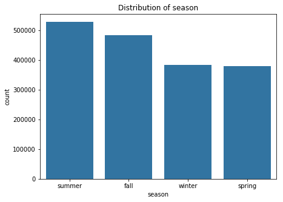

```python
plt.figure(figsize=[7,5])
base_color=sb.color_palette()[0]
season_order=ford_df_clean['season'].value_counts().index
sb.countplot(data=ford_df_clean,x='season',color=base_color,order=season_order);
plt.title("Distribution of season");
```

**The Frequency distribution of seasons shows that, maximum number of bike trips happens in Summer season and moderately lower number in fall and the lowest in winter and spring seasons.**

#### Which day of the week records for the maximum bike rides

```python
ford_df_clean.start_time_weekday.value_counts()
```

```
Wed    307579
Thu    307494
Tue    305808
Mon    283594
Fri    275203
Sat    156064
Sun    135262
Name: start_time_weekday, dtype: int64
```

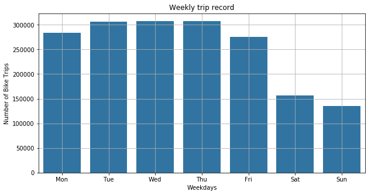

```python
plt.figure(figsize=[10,5])
weekday = ['Mon', 'Tue', 'Wed', 'Thu', 'Fri', 'Sat', 'Sun']
sb.countplot(data=ford_df_clean,x='start_time_weekday',color=base_color,order=weekday);
plt.xlabel("Weekdays")
plt.ylabel("Number of Bike Trips")
plt.title('Weekly trip record');
plt.grid(True)
```

**The maximum number of bike trips is recorded on Wednesdays,however, there is marginal difference with thursdays and tuesdays. Alos, weekends records the lowest number of bike trips. Probably due to non-working days.**

#### Hourly usage of bike service in terms of proportions (During what time of the day bike rides are recorded most)

```python
ford_df_clean.start_time_hour.value_counts()
```

```
17    212929
8     203633
18    165809
9     155711
16    135364
19    100095
7      99754
15     88301
12     81667
13     78833
10     77654
14     74636
11     71817
20     64411
21     45520
6      34938
22     29772
23     17846
0       9748
5       9371
1       5652
2       3472
4       2054
3       2017
Name: start_time_hour, dtype: int64
```

```python
#get proportion
n_points=ford_df_clean.shape[0]
max_count=ford_df_clean['start_time_hour'].value_counts().max()
max_prop=max_count/n_points
```

```python
#generate tick mark locations and names

tick_props=np.arange(0,max_prop,0.01)
tick_names=['{:0.2f}'.format(v) for v in tick_props]
```

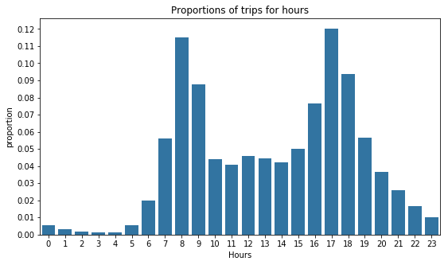

```python
# hourly usage of the bike sharing systems
plt.figure(figsize=(9,5))
sb.countplot(data=ford_df_clean,x='start_time_hour',color=base_color)
plt.yticks(tick_props*n_points,tick_names)
plt.ylabel('proportion')
plt.xlabel('Hours');
plt.title("Proportions of trips for hours");
```

**Graph is a bimodal distribution with the maximum percentage of trips occuring during peak(working) hours of 8am and also at around 5pm Could be because that's when people get to and back from the work.**

#### Frequency distribution of Duration(min)

```python
ford_df_clean.duration_min.describe()
```

```
count    1.771004e+06
mean     1.278873e+01
std      3.175064e+01
min      1.016667e+00
25%      5.716667e+00
50%      9.000000e+00
75%      1.391667e+01
max      1.438017e+03
Name: duration_min, dtype: float64
```

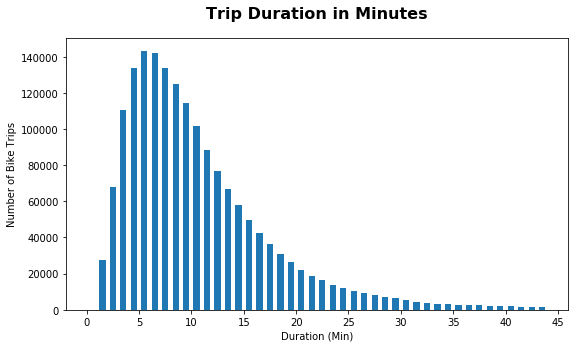

```python
# Duration of the bike rides -in MINUTES
bin_edges = np.arange(0, 45, 1)
ticks = [0, 5, 10, 15, 20, 25, 30,  35, 40, 45]
labels = ['{}'.format(val) for val in ticks]

plt.figure(figsize=[9,5])
plt.hist(data = ford_df_clean, x = 'duration_min', bins = bin_edges, rwidth = 0.6);
plt.title("Trip Duration in Minutes", y=1.05, fontsize=16, fontweight='bold')
plt.xlabel('Duration (Min)')
plt.xticks(ticks, labels)
plt.ylabel('Number of Bike Trips');
```

**It shows a Right skewed distribution, on an average,trips were of short duration of 5 to 10 mins with 75% of trips being under 14 minutes.This suggests the majority of bikers avail for short duration trips.**

#### Usage based on gender

```python
# Usage by females, males, and other
gender = ford_df_clean.member_gender.value_counts()/n_points
gender
```

```
Male      0.732255
Female    0.251668
Other     0.016077
Name: member_gender, dtype: float64
```

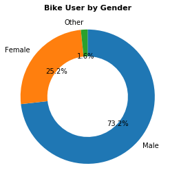

```python
plt.pie(gender,labels=gender.index, autopct='%1.1f%%',startangle=90,counterclock=False,wedgeprops={'width':0.4});
plt.axis('square');
plt.title('Bike User by Gender', y=1.05, fontsize=11, fontweight='bold');
```

#### Data based on age group

```python
ford_df_clean.age.max(),ford_df_clean.age.mean()
```

```
(59.0, 34.82841427800276)
```

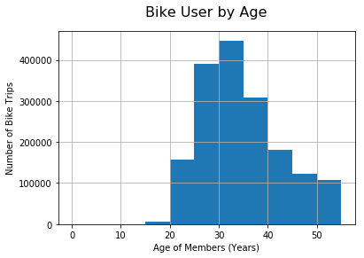

```python
# Age group data
bin_edges = np.arange(0, 60, 5)

plt.hist(data = ford_df_clean, x = 'age', bins = bin_edges);

plt.title("Bike User by Age", y=1.05, fontsize=16)
plt.xlabel('Age of Members (Years)')
plt.ylabel('Number of Bike Trips');
plt.grid(True)
```

**Considering age group upto 60 years, The histogram shows the majority of users fall between the ages of 25 - 40 years, which is also the same age range of the working adults.**

#### Types of Bike Users

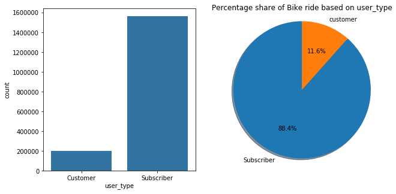

```python
plt.figure(figsize = [10, 5])
plt.subplot(1,2,1)
sb.countplot(data = ford_df_clean, x = 'user_type', color = base_color);

plt.subplot(1,2,2);

labels = ['Subscriber', 'customer']
plt.pie(ford_df_clean.user_type.value_counts(), autopct='%1.1f%%',labels=labels, shadow=True, startangle=90);

plt.axis('square');
plt.title("Percentage share of Bike ride based on user_type");
```

**Majority of the Bike Users are subscribers ,With the 88.4% of trips are utilized by Subscriber(88.4%) than occasional users(11.6%)**

### Of the features you investigated, were there any unusual distributions? Did you perform any operations on the data to tidy, adjust, or change the form of the data? If so, why did you do this?

There was one unusal distribution for the member birth year, which in some cases was dated before 1900. Since 95% of the members are between 17 and 57 years, I removed users older than 60.

### Bivariate Exploration

Main focus here is on exploring User_type and its relationship with other features.

#### User_type vs member_gender

```python
ct_counts=ford_df_clean.groupby(['member_gender','user_type']).size().reset_index(name='count')
```

```python
#rearrange the data
visu=ct_counts.pivot(index='member_gender',columns='user_type',values='count')
visu
```

| user_type member_gender | Customer | Subscriber |
| --- | --- | --- |
| Female | 63798 | 381907 |
| Male | 136731 | 1160095 |
| Other | 4205 | 24268 |

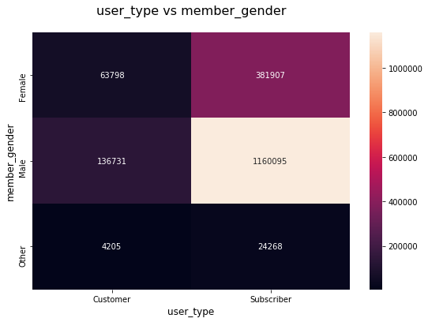

```python
plt.figure(figsize=[9,6])
sb.heatmap(visu,annot=True,fmt='d');
plt.title('user_type vs member_gender',fontsize=16,y=1.05);
plt.xlabel('user_type',fontsize=12)
plt.ylabel('member_gender',fontsize=12);
```

**The heatmap above depicts majority of Subscribers are Male with thrice the number of Female Subscribers.The same trend is seen in the customer riders as well.Suggesting irrespective of User_type, Male bikers are more than Female bikers and others.**

#### User_type vs Season

```python
#convert season column to category
season=['winter','spring','summer','fall']
seasclasses=pd.api.types.CategoricalDtype(ordered=True,categories=season)
ford_df_clean['season']=ford_df_clean['season'].astype(seasclasses)
```

```python
ford_df_clean.dtypes
```

```
duration_sec                        int64
start_time                 datetime64[ns]
end_time                   datetime64[ns]
start_station_id                   object
start_station_name                 object
start_station_latitude            float64
start_station_longitude           float64
end_station_id                     object
end_station_name                   object
end_station_latitude              float64
end_station_longitude             float64
bike_id                            object
user_type                        category
member_birth_year                 float64
member_gender                    category
bike_share_for_all_trip          category
start_time_month_name              object
start_time_month                    int32
start_time_weekday                 object
start_time_hour                     int64
age                               float64
season                           category
duration_min                      float64
dtype: object
```

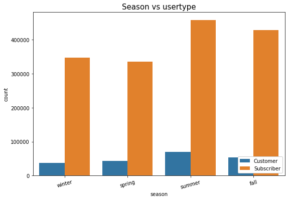

```python
#Plotting
plt.figure(figsize=[9,6])
ax=sb.countplot(data=ford_df_clean,x='season',hue='user_type')
ax.legend(loc=4,framealpha=1)
plt.xticks(rotation=15)
plt.title("Season vs usertype",fontsize=15);
```

#### Usertype vs Duration

```python
# scatter plot of duration_min vs. member_age, with log transform on duration_min axis
samples = np.random.choice(ford_df_clean.shape[0], 5000, replace = False)
samp = ford_df_clean.loc[samples,:]
```

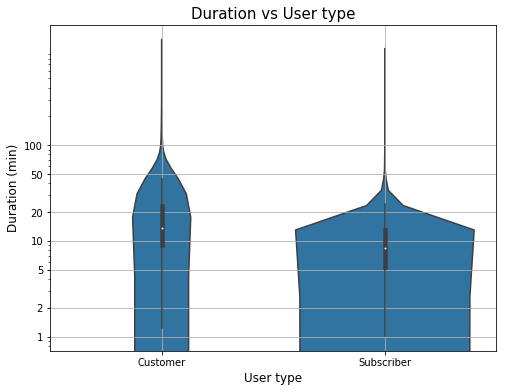

```python
plt.figure(figsize = [8, 6]);
sb.violinplot(data = samp, x = 'user_type', y = 'duration_min',color=base_color);
plt.xlabel('User type',fontsize=12);
plt.yscale('log');
plt.yticks([1, 2, 5, 10, 20, 50, 100], [1, 2, 5, 10, 20, 50, 100]);
plt.ylabel('Duration (min)',fontsize=12);
plt.title("Duration vs User type",fontsize=15);
plt.grid(True)
```

**Contrary to previous graph, Customers are the winners here.**

#### Ford GoBike System Trends by User Type

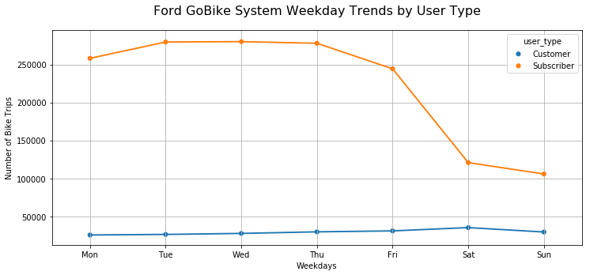

```python
# Customer Usage by Weekday vs. Subscriber Usage by Weekday
plt.figure(figsize=(12, 5))

ford_df_clean_user_week = ford_df_clean.groupby(['start_time_weekday', 'user_type']).size().reset_index()
weekday = ['Mon', 'Tue', 'Wed', 'Thu', 'Fri', 'Sat', 'Sun']

ax = sb.pointplot(data=ford_df_clean_user_week, x='start_time_weekday', y=0, hue = 'user_type', scale=.7, order = weekday);

plt.title('Ford GoBike System Weekday Trends by User Type', y=1.05, fontsize=16)
plt.xlabel('Weekdays')
plt.ylabel('Number of Bike Trips');
plt.grid()
```

```python
ford_df_clean_user_week.max()
```

```
start_time_weekday           Wed
user_type             Subscriber
0                         279985
dtype: object
```

**The point plot above shows the sharp contrast between Customers and Subscribers. Customers have a relatively low usage of the bike share system(showing almost constant graph) with a small increase on the weekends.On the contrary,Subscribers have steadily high usage on weekdays, with a sharp decline on the weekends.**

#### Start_time_hour vs user_type

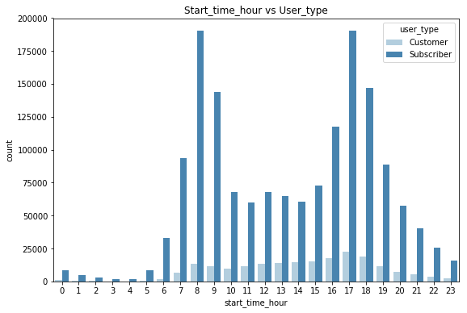

```python
plt.figure(figsize=[9,6])
sb.countplot(data = ford_df_clean, x = 'start_time_hour', hue = 'user_type', palette = 'Blues');
ax.legend(loc = 1, ncol = 2);
plt.title("Start_time_hour vs User_type");
```

**Bimodal distribution depicts that,8.00AM and 5:00 PM have the most Subscribers compared to other hours. User_type doesn't impact much on start_time_hour as the above distribution is same as univariate distribution of 'start_time_hour'.**

#### Talk about some of the relationships you observed in this part of the investigation. How did the feature(s) of interest vary with other features in the dataset?

Adding the user type to the analysis revealed different behavior usage between customers and subscribers. The data suggests that customers are casual riders such as tourists, or students on a school vacation or holiday. This is accurate when factoring in that Customer usage increases on the weekends,making longer trips. In contrast, the data suggests Subscribers are daily commuters or full time students who use the system during weekdays, better weather, and mostly for shorter distances. They mainly rent bikes before and after a typical work or school day (8-9am and 5-6pm).

#### Did you observe any interesting relationships between the other features (not the main feature(s) of interest)?¶

There is a difference in the trip duration between customers and subscribers. Customers trips are usually longer than subscribers, most probably due to the fact they prefer bike rides around weekends in summertime, which may be for longer trips around the surrounding area. Subscribers use the system mainly for commute purposes so they prefer quick, short rides to and from work.

## Multivariate Exploration

I created plots of three or more variables to investigate the Ford Go Bike data even further.

```python
ford_df_clean.age.describe()
```

```
count    1.771004e+06
mean     3.482841e+01
std      8.947861e+00
min      1.800000e+01
25%      2.800000e+01
50%      3.300000e+01
75%      4.000000e+01
max      5.900000e+01
Name: age, dtype: float64
```

```python
#create a new column for age groups.
age_labels=['15-25','26-35','36-45','46-55','56-66']
bin_edges=[15,25,35,45,55,65]
ford_df_clean['age_group']=pd.cut(ford_df_clean.age,bin_edges,labels=age_labels)
```

#### Relationship between Duration_min, User_type for different age_groups and member_gender

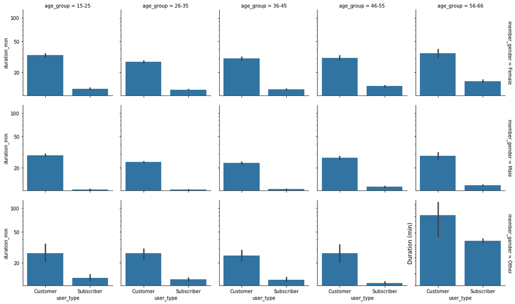

```python
g=sb.FacetGrid(data=ford_df_clean,col='age_group',row='member_gender',margin_titles=True);
g.map(sb.barplot,'user_type','duration_min');
plt.yscale('log')
plt.yticks([1, 2, 5, 10, 20, 50, 100], [1, 2, 5, 10, 20, 50, 100]);
plt.ylabel('Duration (min)',fontsize=12);
#plt.title("Duration vs User type",fontsize=15);
```

As we saw in the Bivariate plot between Usertype and duration,It was customers who took longer trips compared to Subscribers.

However,The above plot explores even further with various age_groups and gender.Overall trend looks like,

1.Duation of the trips taken by **Male Customers and Male Subscibers** are relatively **lesser** than the rest across all age-groups

2.Among all the age groups,people belonging to **55-66yrs** availed bikes for long duration trips.

3.People of **other gender** of 55-66yrs made the maximum long trips compared to rest of them of that age group.

4.Female:short trips-26-35yrs, Long trips-55-66yrs

5.Male:Short trips-36-45yrs, Long trips-55-66yrs

6.Other:36-45ys, Long trips-55-66yrs.

#### Hourly usage during the weekday for customers and subscribers

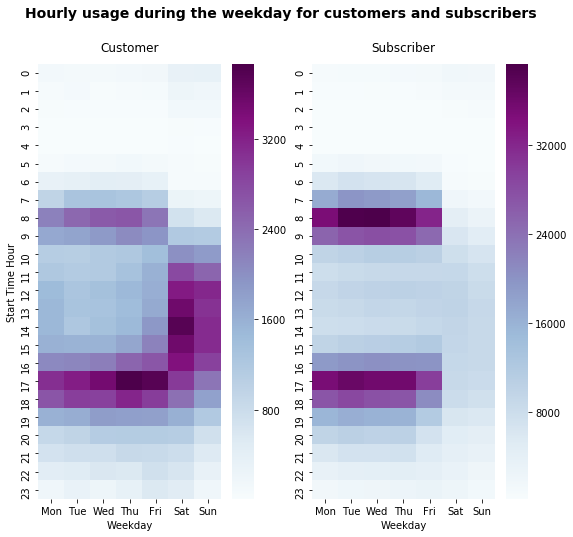

```python
# Setting the weekday order
ford_df_clean['start_time_weekday'] = pd.Categorical(ford_df_clean['start_time_weekday'],
                                                categories=['Mon','Tue','Wed','Thu','Fri','Sat', 'Sun'],
                                                ordered=True)
plt.figure(figsize=(9,8))
plt.suptitle('Hourly usage during the weekday for customers and subscribers', fontsize=14, fontweight='semibold')

# heatmap for customers
plt.subplot(1, 2, 1)
df_customer = ford_df_clean.query('user_type == "Customer"').groupby(["start_time_hour", "start_time_weekday"])["bike_id"].size().reset_index()
df_customer = df_customer.pivot("start_time_hour", "start_time_weekday", "bike_id")
sb.heatmap(df_customer,cmap="BuPu")

plt.title("Customer", y=1.015)
plt.xlabel('Weekday')
plt.ylabel('Start Time Hour')

# heatmap for subscribers
plt.subplot(1, 2, 2)
df_subscriber = ford_df_clean.query('user_type == "Subscriber"').groupby(["start_time_hour", "start_time_weekday"])["bike_id"].size().reset_index()
df_subscriber = df_subscriber.pivot("start_time_hour", "start_time_weekday", "bike_id")
sb.heatmap(df_subscriber,cmap="BuPu")
plt.title("Subscriber", y=1.015)
plt.xlabel('Weekday')
plt.ylabel('');
```

The plot summarizes the following:

**Customers use the bike sharing system more often on weekends:**

weekdays: most bike rides happen around 8-9am and 5-6pm with the peak on Fridays around 5pm

weekends: most bike rides happen between 10am - 8pm with the peak on Saturdays around 2pm

**Subscribers use the bike sharing system mainly on weekdays:**

weekdays: most bike rides happen around 8-9am and 5-6pm with the peak on Tuesdays around 8am

weekends: bikes are still rented but there is a significant drop in numbers of rented bikes throughout the entire weekends

#### Hourly usage of the bike share system per user type and gender

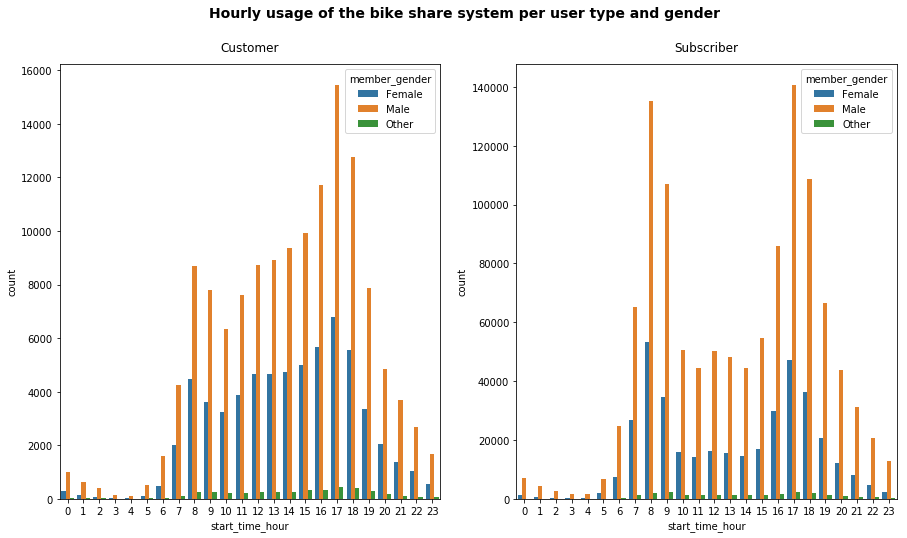

```python
plt.figure(figsize=(15,8))
plt.suptitle('Hourly usage of the bike share system per user type and gender', fontsize=14, fontweight='semibold')


# clustered barplots for customers
plt.subplot(1, 2, 1)
df_customer=ford_df_clean.query('user_type=="Customer"')
sb.countplot(data=df_customer,x='start_time_hour',hue='member_gender')
plt.title("Customer", y=1.015);


plt.subplot(1,2,2)
df_subscriber=ford_df_clean.query('user_type=="Subscriber"')
sb.countplot(data=df_subscriber,x='start_time_hour',hue='member_gender')
plt.title("Subscriber", y=1.015);
```

**During the day, both males and females use the system the same way: customers use bikes mainly between 8 am - 7 pm; subscribers on the other side use the system at around 8-9am and 5-6pm when they go and come back from work.**

#### weekly usage by customers and subscribers of different genders

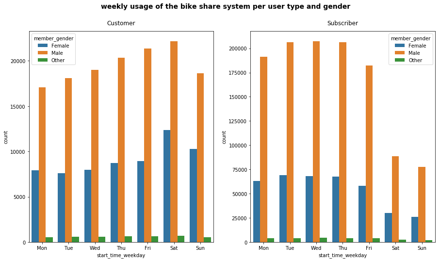

```python
plt.figure(figsize=(15,8))
plt.suptitle('weekly usage of the bike share system per user type and gender', fontsize=14, fontweight='semibold')


# clustered barplots for customers
plt.subplot(1, 2, 1)
df_customer=ford_df_clean.query('user_type=="Customer"')
sb.countplot(data=df_customer,x='start_time_weekday',hue='member_gender')
plt.title("Customer", y=1.015);


plt.subplot(1,2,2)
df_subscriber=ford_df_clean.query('user_type=="Subscriber"')
sb.countplot(data=df_subscriber,x='start_time_weekday',hue='member_gender')
plt.title("Subscriber", y=1.015);
```

**As in the previous section, the trend is very similar for males and females: customers use the system more often during weekends than within a week (although the jump in bike used on weekends is much higher for females than for males); subscribers use the system mainly within a week.**

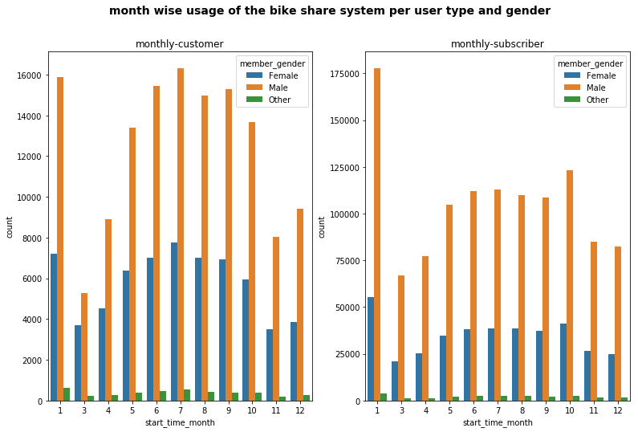

```python
plt.figure(figsize=(13,8))
plt.suptitle('month wise usage of the bike share system per user type and gender', fontsize=14, fontweight='semibold')


# clustered barplots for customers

plt.subplot(1,2,1)
sb.countplot(data=df_customer,x='start_time_month',hue='member_gender')
plt.title("monthly-customer");

plt.subplot(1,2,2)
sb.countplot(data=df_subscriber,x='start_time_month',hue='member_gender')
plt.title("monthly-subscriber");
```

**Reproducing same plot but with start_time_month. The trend is very similar for males and females:**

**for customers, the highest demand is around summertime, reaching its peak in July; as well as January**

### Talk about some of the relationships you observed in this part of the investigation. Were there features that strengthened each other in terms of looking at your feature(s) of interest?

1.Subscriber vs Customer age was expanded upon through the use of age groups. visuals based on age group showed ,young adults(25-40yrs) made short trips than elderly people(55-66yrs),who utilised bikes solely for long trips regardless of gender.

2.Plotting a heatmap of when bikes are high in demand throughout the day on each weekday shed light on the customers behaviour.